# General documents for applying for admission into a Master’s

Getting paperword in order

application

Published

July 19, 2021

# General documents for applying for admission into a Master’s

No matter which [Master’s one has searched for](https://luisavasquez.github.io/quiescens-lct/posts/2021-06-26-searching-masters.html), there are some documents that most Master’s programs require.

# Proof of language proficiency

If your program is in English, TOEFL or IELTS are usually accepted, and each program has its minimum grade requirements.

I took the TOEFL, which in 2019 cost about 200 USD

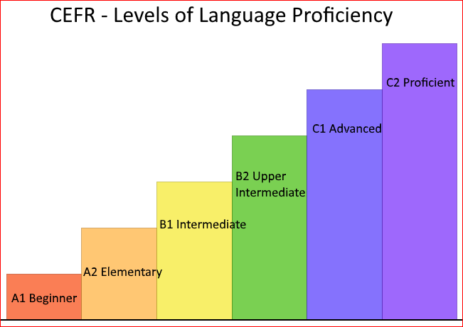

# Bachelor’s Degree

This certifies that you finished your undergraduate students.

Some specific countries may have a degree between a Bachelor and a Master’s degree. For example, Peru has a “licensing” process to get a Licensed Degree. This kind of processes are not necessary to apply abroad.

I had to get my Bachelor’s degree translated and apostilled.

Note, some universities, like mine, can also issue certified copies of a Bachelor’s degree. This can also be useful to get.

[figure not shown]

# Transcript of courses

This is a list with all your grades from your undergraduate years. It is very helpful if it includes a note explaining the grading system at your university.

If you made and exchange abroad during your undergrad, then the transcript from those courses could also help you in your application. Imagine the election committee wondering “Hey, why didn’t this person take such and such course? Ah, this person took it abroad, nice!”.

I had to get my transcripts translated and [apostilled](https://luisavasquez.github.io/quiescens-lct/posts/2021-07-02-apostille.html).

# Motivation letter

A letter explaining your background, and why you want to pursue the Master. It should be written separately for each university you’re applying to.

Writing the motivation letter deserves its own post.

The good thing, is that election committees do look at motivation letters, unlike others….

[figure not shown]

# Curriculum Vitae

Even this should be tailored to each specific program. Add, remove, and reorder the items in your CV to fit the Master’s you’re applying to.

For example, if you have an educational background in one area, and work experience in another area, then you can order them putting first the one most relevant to the Master’s.

Some Master’s have length limitations (usually two pages) for CVs.

[figure not shown]

# Recommendation letters

Usually two recommendation letters are requested.

They should be written by people with whom you have actually worked and that know and have evidence of your abilities.

If you ask a professor, ideally it should be someone with whom you made a research project, or a mentor that knows you for many years, or your undergraduate thesis advisor, etc. If the only thing a professor can say about you is “this person made good questions during class” or “this person had a cool final essay”, then look for another professor.

If you ask someone from a job, you’re trying on hard terrain. Your job should be relevant to the subject area of your Master’s. You could ask your boss or a supervisor, but this person has to have credentials in the subject area of your Master’s as well. On the upside, the election committee will know that someone from your job is concerned only about your real and tangible abilities to get things done, and will not lie to make you look good.

In my case, I asked four persons for letters of recommendation: three professors and one boss.

- With the first professor I had made an undergraduate Math research project on Control Theory, and he was my mentor for some years.
- With the second professor I took an intense one on one Graduate Algebra Seminar (no one else registered!) so he got to see me handling new and advanced topics.
- With the third professor I was part of his reading circle on Linguistics, Logic, and Philosophy of Language for many years, so he knew my point of view regarding those topics, which were influential when I changed my major to Mathematics.
- Finally, my boss was a physicist and worked as a senior programmer for many years, and he supervised me on a work project for a year.

Additionally, I was strategic choosing which professors sent their recommendations to which universities.

For the more technical Master’s programs I asked my math professors or my boss to send their recommendations; for the more interdisciplinary Master’s programs I asked both my math and humanities (linguistics) professors to send their recommendations.

[figure not shown]

# Others:

## GRE/GMAT

I have [already explained](https://luisavasquez.github.io/quiescens-lct/posts/2021-06-26-searching-masters.html) that to me the [GRE](https://en.wikipedia.org/wiki/Graduate_Record_Examinations) and the [GMAT](https://en.wikipedia.org/wiki/Graduate_Management_Admission_Test) seem to be more a hassle to impede large numbers of students from applying, and that’s why I chose to avoid Master’s requiring either of them. However, it’s still a kind of common request.

## Diplomas

Documents indicating a good overall ranking in your graduation batch, or certificates of good performance in championships, competitions, bootcamps, etc, that make you look good could help your application, if they seem relevant to the election committee. They’re not necessary, so send them only if you think they could help.

Some applications also ask for a **High School Diploma**, and in general, once accepted, European universities request them as well.

## Criminal records

If you need to apply for an internship at some point, they will probably ask for a Criminal record. Normally, you can get them at your Embassy abroad, but it is normally easier to get them in your own country, and have them Apostilled!

> Good luck!